# Developing Data Products: Predict house price

09/03/2019

## Project goal

This app is a simulator which predict [House Sales in King County, Washington State, USA](https://www.kaggle.com/harlfoxem/housesalesprediction) function of multiples criterias. The dataset can be retrieved from the [Kaggle](https://www.kaggle.com) platform.

This App is built as part as the coursera Developing Data Products course Peer-graded Assignment.

This **peer assessed assignment** has two parts.

- First, a Shiny application and deployed on Rstudio's servers.
- Second, and second the present reproducible pitch presentation about my application.

```r
head(raw_house, 20)
```

| id | date | price | bedrooms | bathrooms | sqft_living | sqft_lot | floors | waterfront | view | condition | grade | sqft_above | sqft_basement | yr_built | yr_renovated | zipcode | lat | long | sqft_living15 | sqft_lot15 | year | month | week |
| --- | --- | --- | --- | --- | --- | --- | --- | --- | --- | --- | --- | --- | --- | --- | --- | --- | --- | --- | --- | --- | --- | --- | --- |
| 7129300520 | 20141013 | 221900 | 3 | 1.00 | 1180 | 5650 | 1.0 | 0 | 0 | 3 | 7 | 1180 | 0 | 1955 | 0 | 98178 | 47.5112 | -122.257 | 1340 | 5650 | 2014 | 10 | 41 |
| 6414100192 | 20141209 | 538000 | 3 | 2.25 | 2570 | 7242 | 2.0 | 0 | 0 | 3 | 7 | 2170 | 400 | 1951 | 1991 | 98125 | 47.7210 | -122.319 | 1690 | 7639 | 2014 | 12 | 49 |
| 5631500400 | 20150225 | 180000 | 2 | 1.00 | 770 | 10000 | 1.0 | 0 | 0 | 3 | 6 | 770 | 0 | 1933 | 0 | 98028 | 47.7379 | -122.233 | 2720 | 8062 | 2015 | 2 | 8 |
| 2487200875 | 20141209 | 604000 | 4 | 3.00 | 1960 | 5000 | 1.0 | 0 | 0 | 5 | 7 | 1050 | 910 | 1965 | 0 | 98136 | 47.5208 | -122.393 | 1360 | 5000 | 2014 | 12 | 49 |
| 1954400510 | 20150218 | 510000 | 3 | 2.00 | 1680 | 8080 | 1.0 | 0 | 0 | 3 | 8 | 1680 | 0 | 1987 | 0 | 98074 | 47.6168 | -122.045 | 1800 | 7503 | 2015 | 2 | 7 |
| 7237550310 | 20140512 | 1225000 | 4 | 4.50 | 5420 | 101930 | 1.0 | 0 | 0 | 3 | 11 | 3890 | 1530 | 2001 | 0 | 98053 | 47.6561 | -122.005 | 4760 | 101930 | 2014 | 5 | 19 |
| 1321400060 | 20140627 | 257500 | 3 | 2.25 | 1715 | 6819 | 2.0 | 0 | 0 | 3 | 7 | 1715 | 0 | 1995 | 0 | 98003 | 47.3097 | -122.327 | 2238 | 6819 | 2014 | 6 | 25 |
| 2008000270 | 20150115 | 291850 | 3 | 1.50 | 1060 | 9711 | 1.0 | 0 | 0 | 3 | 7 | 1060 | 0 | 1963 | 0 | 98198 | 47.4095 | -122.315 | 1650 | 9711 | 2015 | 1 | 2 |
| 2414600126 | 20150415 | 229500 | 3 | 1.00 | 1780 | 7470 | 1.0 | 0 | 0 | 3 | 7 | 1050 | 730 | 1960 | 0 | 98146 | 47.5123 | -122.337 | 1780 | 8113 | 2015 | 4 | 15 |
| 3793500160 | 20150312 | 323000 | 3 | 2.50 | 1890 | 6560 | 2.0 | 0 | 0 | 3 | 7 | 1890 | 0 | 2003 | 0 | 98038 | 47.3684 | -122.031 | 2390 | 7570 | 2015 | 3 | 10 |

[output cut: 10 more lines]

## Training

The dataset contains 21613 rows and 24 variables taken over a year.

```r
set.seed(99)
house <- raw_house[, -nearZeroVar(raw_house)]
dataPartitions <- createDataPartition(y = house$price, p = 0.7, list = F)
training <- house[dataPartitions, ]
validation <- house[-dataPartitions, ]
trControl <- trainControl(method = 'repeatedcv', number = 8, repeats = 3,
                          allowParallel = TRUE, verboseIter = FALSE)
modGbm <- train(price ~ zipcode + grade + condition + sqft_lot + bedrooms + week,
                data = training, method = 'gbm', trControl = trControl, verbose = F)
predGbm <- predict(modGbm, validation)
accGbm <- accuracy(predGbm, validation$price)
```

## Average price per zipcode (data exploration)

The main panel and default tab is a **leaflet** interactive map, all the individuals transactions grouped by cluster function on the density displayed in the map. The value in the cluster in the count of the transactions. The user can then freely explore the map to get a taste of the market in different places. Both transactions and aggregates are filtered by the `Subset by price` slider.

The circles show the aggregated data per zipcode.

- the `lat` and `long` coordinate are the median value between the house positions for each `zipcode`.
- the `radius` of the circle is the count of houses
- the `colour` of the circle is the average **price** for the `zipcode` area.

## Price Prediction

The user can then enter the prediction tab where the predicted and validation dataset prices are displayed per zipcode.

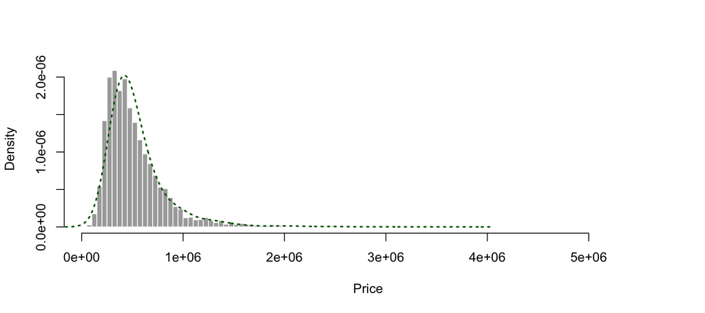

```r
hist(validation$price, breaks = 90, freq = FALSE, col = 'darkgray', border = 'white', xlab = 'Price', main = '')
lines(density(predGbm, adjust = 4), lty = 'dotted', col = 'darkgreen', lwd=2)
```